# ggplot2

ggplot2 David Jorgensen 2021

`ggplot2` uses a “grammar of graphics” format to describe the data, aesthetics and geometry of a plot. A list of available geometries can be found here: https://ggplot2.tidyverse.org/reference/

And a list of all aesthetics can be found here: https://ggplot2.tidyverse.org/articles/ggplot2-specs.html

Further packages which are based on ggplot can be found here: https://exts.ggplot2.tidyverse.org/gallery/

Before we get started we will need to load the package `ggplot2`

```r
library(ggplot2)
```

For the following examples we will use the iris dataset, a default dataset in R.

As we have seen you can `View()` this data to see it in table format and `str()` to see a summary of the structure of the data. Try running these in your Rstudio window:

```r
View(iris)
```

```r
str(iris)
```

```
## 'data.frame':    150 obs. of  5 variables:
##  $ Sepal.Length: num  5.1 4.9 4.7 4.6 5 5.4 4.6 5 4.4 4.9 ...
##  $ Sepal.Width : num  3.5 3 3.2 3.1 3.6 3.9 3.4 3.4 2.9 3.1 ...
##  $ Petal.Length: num  1.4 1.4 1.3 1.5 1.4 1.7 1.4 1.5 1.4 1.5 ...
##  $ Petal.Width : num  0.2 0.2 0.2 0.2 0.2 0.4 0.3 0.2 0.2 0.1 ...
##  $ Species     : Factor w/ 3 levels "setosa","versicolor",..: 1 1 1 1 1 1 1 1 1 1 ...
```

You can see from this that it is a basic data frame with observations across the columns and individual samples along the rows.

This document will run through some of the most common plot types you will likely want to use in R

## Histogram

First we will plot a simple histogram. This features in the Stegen case study but here we will go into more depth with formatting.

We specify the histogram by providing 1) Data (`data=iris`) 2) mapping (we want to plot sepal length on the X-axis: `aes(x = Sepal.Length)`) 3) geometry - we want a histogram (`geom_histogram()`).

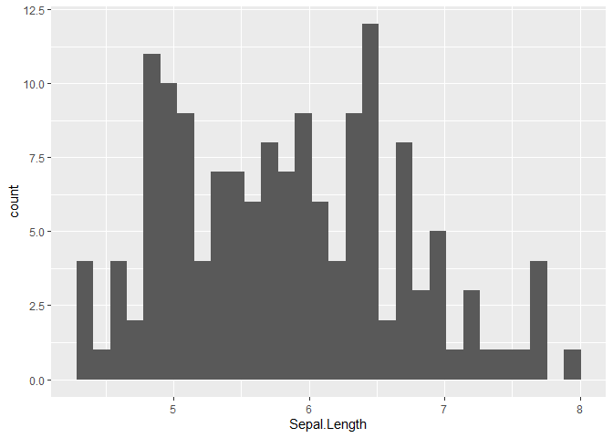

```r
ggplot(data  = iris, aes( x = Sepal.Length)) +
  geom_histogram()
```

You will see a message when you run this code about binwidth. As `Sepal.length` is a continuous variable the histogram can be plotted with bars of multiple widths.

We can specify the width in two ways. first with the width of the bins we would like to see:

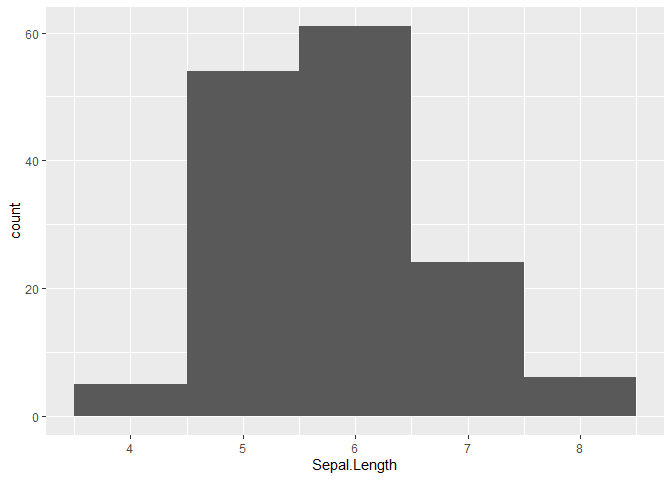

```r
ggplot(data  = iris, aes( x = Sepal.Length)) +
  geom_histogram(binwidth=1)
```

Second, with the number of bins we want to include:

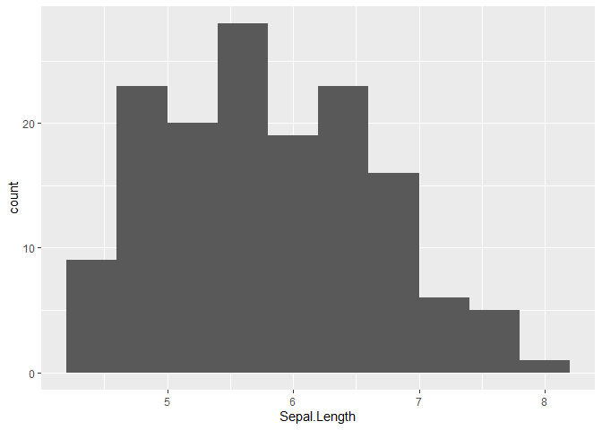

```r
ggplot(data = iris , aes(x=Sepal.Length)) +
  geom_histogram(bins = 10)
```

### Aesthetics

Say we want to colour the bars to be white, outlined in red, we can do that with the following command:

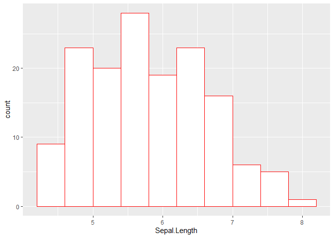

```r
ggplot(data = iris , aes(x=Sepal.Length)) +
  geom_histogram(bins = 10, fill="white", colour="red")
```

**TRY CHANGING THE FILL COLOUR TO ORANGE**

We can also use categorical variables in our data frame to set the colour and fill. To do this they need to be included in the `aes()` argument as we are selecting more data to plot.

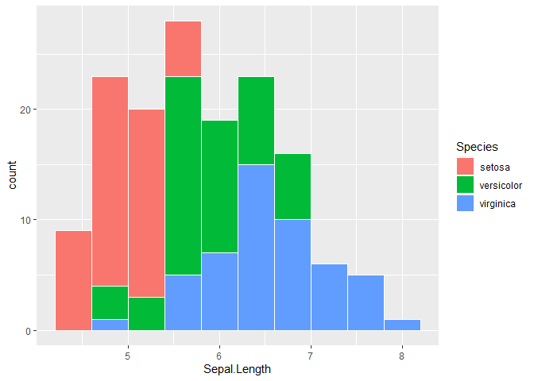

```r
ggplot(data = iris , aes(x=Sepal.Length, fill=Species)) +
  geom_histogram(bins = 10, colour="white")
```

You will see this gives default colours and plots a legend by default. We can change these colours using `scale_fill_manual()`. This can be added (`+`) to the plot:

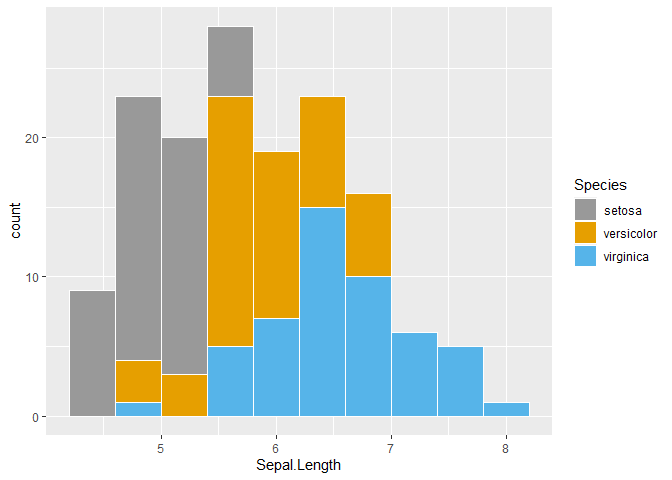

```r
ggplot(data = iris , aes(x=Sepal.Length, fill=Species)) +
  geom_histogram(bins = 10, colour="white")+
  scale_fill_manual(values=c("#999999", "#E69F00", "#56B4E9"))
```

Here I use HEX colours (eg. #999999), a common way of defining colours online. You can also use colour names as we did before.

**Try changing the code above to produce a plot that looks like this using colour names:**

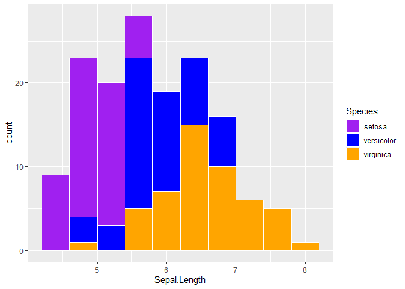

We can also change the opacity of the fill colours using `alpha`:

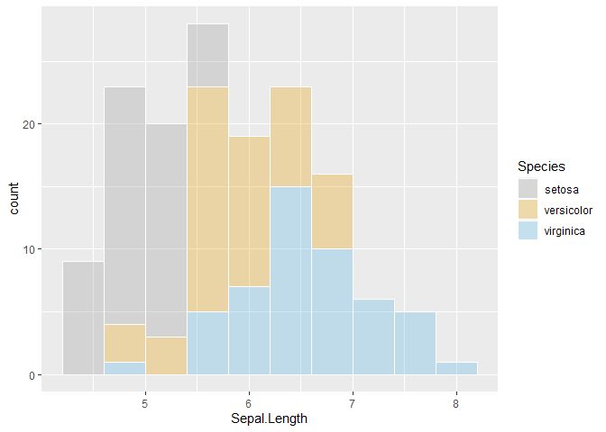

```r
ggplot(data = iris , aes(x=Sepal.Length, fill=Species)) +
  geom_histogram(bins = 10, colour="white", alpha=0.3)+
  scale_fill_manual(values=c("#999999", "#E69F00", "#56B4E9"))
```

### Labels

Plot labels can be changed without changing the underlying names in the data. Here we change the X-axis and Y-axis labels and give the plot a title, again using the `+`

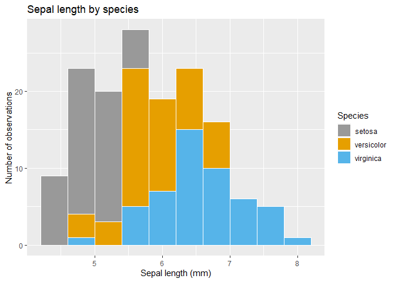

```r
ggplot(data = iris , aes(x=Sepal.Length, fill=Species)) +
  geom_histogram(bins = 10, colour="white")+
  scale_fill_manual(values=c("#999999", "#E69F00", "#56B4E9"))+
  ylab("Number of observations")+
  xlab("Sepal length (mm)")+
  ggtitle("Sepal length by species")
```

We can also change the title of the legend:

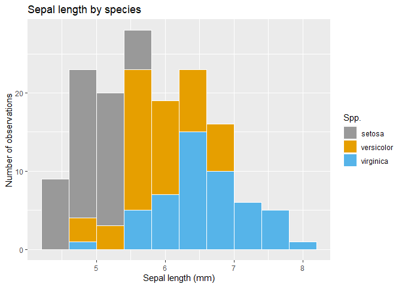

```r
ggplot(data = iris , aes(x=Sepal.Length, fill=Species)) +
  geom_histogram(bins = 10, colour="white")+
  scale_fill_manual(values=c("#999999", "#E69F00", "#56B4E9"),
                    name="Spp.")+
  ylab("Number of observations")+
  xlab("Sepal length (mm)")+
  ggtitle("Sepal length by species")
```

### Themes

ggplot has a number of built in themes other than the default grey background. Some key ones are listed here:

```r
theme_gray()      # default theme
theme_bw()        # dark on light
theme_linedraw()  # black on white
theme_light()     # light grey lines and axes
theme_dark()      # grey lines on dark background
theme_minimal()   # simple background grid
theme_classic()   # axis lines but no gridlines
theme_void()      # no background info
```

For example here is the same plot with the bw theme:

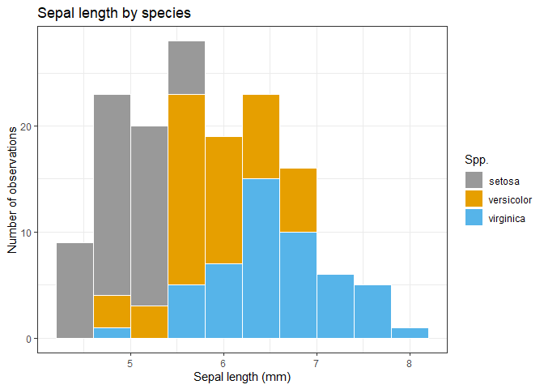

```r
ggplot(data = iris , aes(x=Sepal.Length, fill=Species)) +
  geom_histogram(bins = 10, colour="white")+
  scale_fill_manual(values=c("#999999", "#E69F00", "#56B4E9"),
                    name="Spp.")+
  ylab("Number of observations")+
  xlab("Sepal length (mm)")+
  ggtitle("Sepal length by species")+
  theme_bw()
```

**TRY SOME OF THE OTHER THEMES ON THIS PLOT**

We can also edit parts of the theme manually for more control. Here we move the legend to the bottom of the plot:

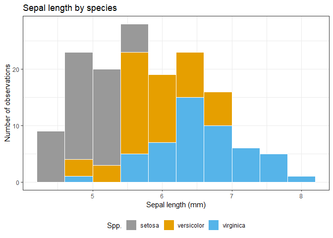

```r
ggplot(data = iris , aes(x=Sepal.Length, fill=Species)) +
  geom_histogram(bins = 10, colour="white")+
  scale_fill_manual(values=c("#999999", "#E69F00", "#56B4E9"),
                    name="Spp.")+
  ylab("Number of observations")+
  xlab("Sepal length (mm)")+
  ggtitle("Sepal length by species")+
  theme_bw()+
  theme(legend.position = "bottom")
```

## Density plot

As the plot aesthetics are separated from the type of plot, we can change to an equivalent plot by changing only the `geom_` argument:

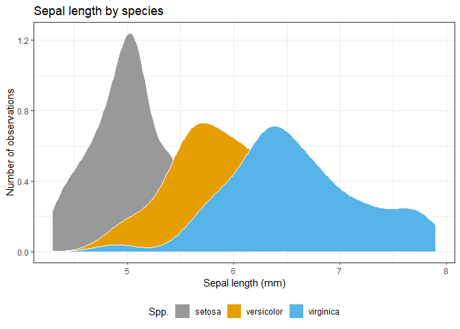

```r
ggplot(data = iris , aes(x=Sepal.Length, fill=Species)) +
  geom_density(colour="white")+
  scale_fill_manual(values=c("#999999", "#E69F00", "#56B4E9"),
                    name="Spp.")+
  ylab("Number of observations")+
  xlab("Sepal length (mm)")+
  ggtitle("Sepal length by species")+
  theme_bw()+
  theme(legend.position = "bottom")
```

**TRY CHANGING THE ALPHA VALUE ON THIS PLOT**

### Facets

Another important operation in ggplot2 is the ability to split a plot out by a categorical variable. For this plot we have decided to view the plot split by Species instead of plotting with overlapping density curves. We do this using the `facet_wrap` function:

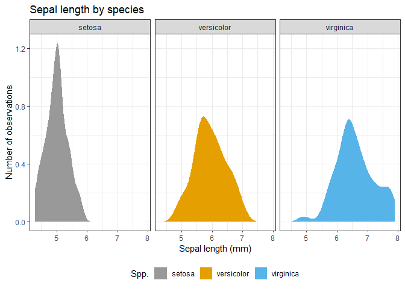

```r
ggplot(data = iris , aes(x=Sepal.Length, fill=Species)) +
  geom_density(colour="white")+
  scale_fill_manual(values=c("#999999", "#E69F00", "#56B4E9"),
                    name="Spp.")+
  ylab("Number of observations")+
  xlab("Sepal length (mm)")+
  ggtitle("Sepal length by species")+
  theme_bw()+
  theme(legend.position = "bottom")+
  facet_wrap(~Species)
```

We can save this plot as an object in our R environment to come back to it later, as with any object:

```r
species_density <- ggplot(data = iris , aes(x=Sepal.Length,
                                            fill=Species)) +
  geom_density(colour="white")+
  scale_fill_manual(values=c("#999999", "#E69F00", "#56B4E9"),
                    name="Spp.")+
  ylab("Number of observations")+
  xlab("Sepal length (mm)")+
  ggtitle("Sepal length by species")+
  theme_bw()+
  theme(legend.position = "bottom")+
  facet_wrap(~Species)
```

## Scatterplot

Scatterplots are another important plot type. In ggplot we specify these with `geom_point`.

Here we plot the sepal length against the petal length from the iris dataset.

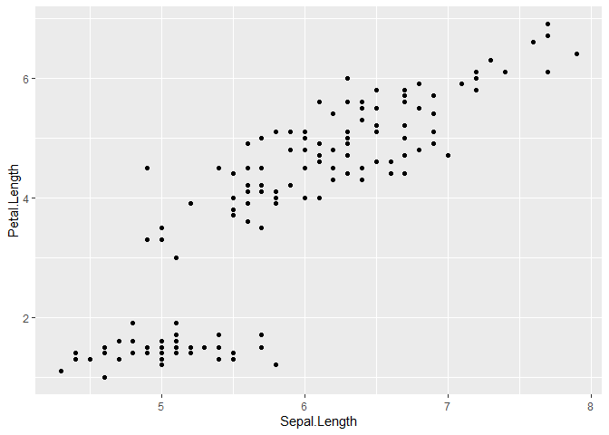

```r
ggplot(data = iris, aes(x = Sepal.Length, y = Petal.Length))+
  geom_point()
```

We can make similar changes to this plot as the plot above.

**TRY COLOURING THE POINTS BY SPECIES**

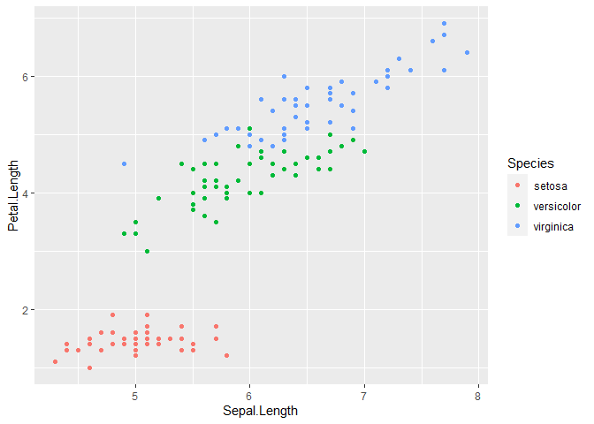

If we plot the same data as a line we will see that setting colour by species will draw an individual line for each set of points.

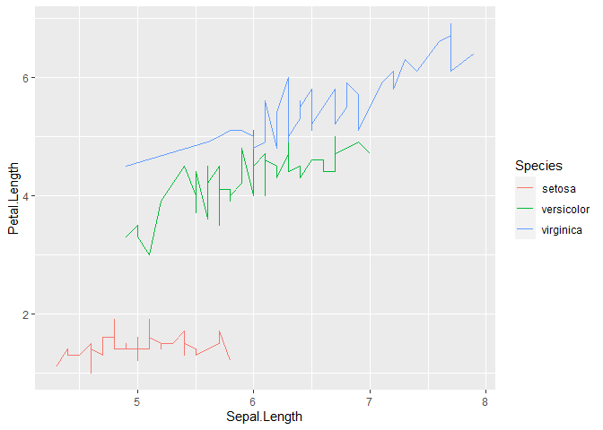

```r
ggplot(data = iris, aes(x = Sepal.Length, y = Petal.Length,
                        colour=Species))+
  geom_line()
```

More usefully, we can fit lines to the point data using `geom_smooth`. By default this uses a loess smoothing method but we can change this to something more useful such as a linear model (`method="lm"`). We use the `aes()` argument to set the fill of the confidence interval to the same as the line and points and alpha to make the fits more transparent.

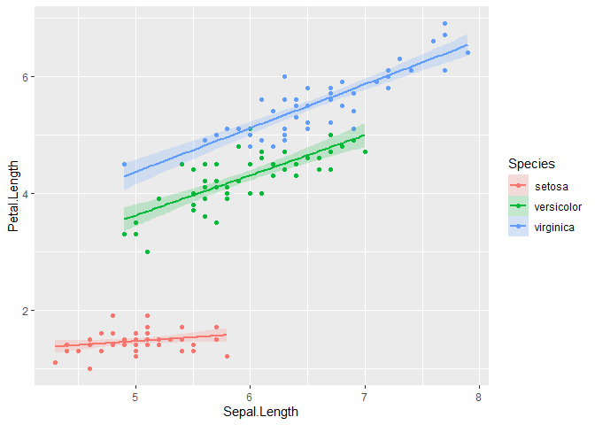

```r
ggplot(data = iris, aes(x = Sepal.Length, y = Petal.Length,
                        colour=Species))+
  geom_point()+
  geom_smooth(method="lm", aes(fill=Species), alpha=0.2)
```

scatter plots have an additional argument to specify the shape of points, `shape`. We can set the shape to change by Species along with the fill:

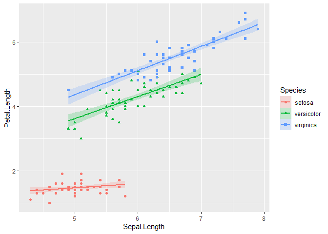

```r
ggplot(data = iris, aes(x = Sepal.Length, y = Petal.Length,
                        colour=Species, shape=Species))+
  geom_point()+
  geom_smooth(method="lm", aes(fill=Species), alpha=0.2)
```

We can also change the point size with `size=` or even make size represent additional data inside the `aes()` argument.

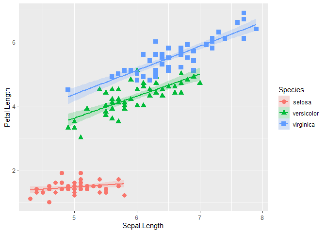

```r
ggplot(data = iris, aes(x = Sepal.Length, y = Petal.Length,
                        colour=Species, shape=Species))+
  geom_point(size=3)+
  geom_smooth(method="lm", aes(fill=Species), alpha=0.2)
```

## Axis limits

There are different ways to set limits on the axes in ggplot. The first is to set limits for both or one of the axes:

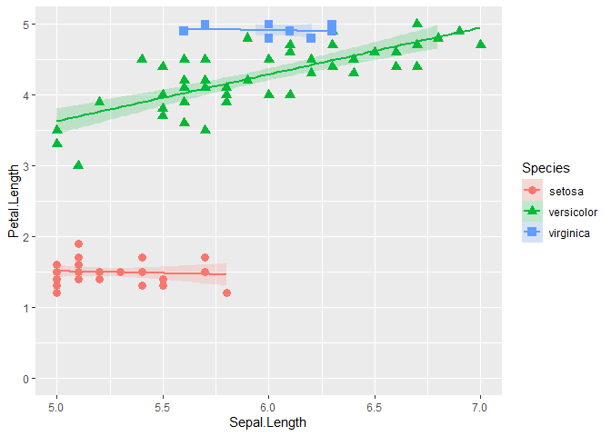

```r
ggplot(data = iris, aes(x = Sepal.Length, y = Petal.Length,
                        colour=Species, shape=Species))+
  geom_point(size=3)+
  geom_smooth(method="lm", aes(fill=Species), alpha=0.2)+
  xlim(5,7)+
  ylim(0,5)
```

If you want to remove the blank space around the plot you will need to use `scale_..._continuous` with the expand argument:

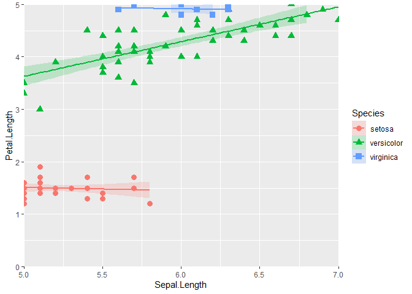

```r
ggplot(data = iris, aes(x = Sepal.Length, y = Petal.Length,
                        colour=Species, shape=Species))+
  geom_point(size=3)+
  geom_smooth(method="lm", aes(fill=Species), alpha=0.2)+
  scale_x_continuous(limits = c(5,7), expand = c(0,0))+
  scale_y_continuous(limits = c(0,5), expand = c(0,0))
```

For maps or other plots where you have polygons which extend beyond the area you want to show, it is better to zoom the plot. You can see this in the plot above where the fitted blue line changes when fewer points are shown on the plot. The `coord_cartesian` function effectively crops the image you are plotting rather than stopping plotting at the coordinates you provide.

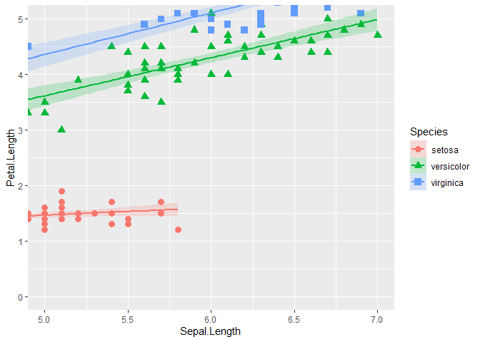

```r
ggplot(data = iris, aes(x = Sepal.Length, y = Petal.Length,
                        colour=Species, shape=Species))+
  geom_point(size=3)+
  geom_smooth(method="lm", aes(fill=Species), alpha=0.2)+
  coord_cartesian(xlim = c(5,7), ylim = c(0,5))
```

## Saving ggplots

There are a number of ways to save plots produced from ggplot2. The simplest is with the export button in the RStudio plots pane. To save from the console or a script ggsave is the easiest method. By default it will save the last plot to your working directory. You can also specify the type of file to save (e.g. pdf, jpg, png), the width, height, dpi etc. of the output image.

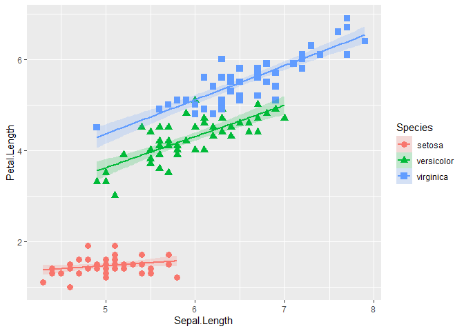

```r
ggplot(data = iris, aes(x = Sepal.Length, y = Petal.Length,
                        colour=Species, shape=Species))+
  geom_point(size=3)+
  geom_smooth(method="lm", aes(fill=Species), alpha=0.2)
```

```r
ggsave(filename = "lm_plot.png")
```

```r
ggsave(filename = "species_density.png", plot=species_density,
       width = 15,height = 10, units = "cm", dpi = 200)
```